# DEFENSIVE TRAITS H.murinum SIBECOL 2025

Andrés Delgado Galán

2025-05-18

### H.murinum - PRODUCCIÓN DE FLORES

**log(flor) ~ trat + clip + trat:clip**  
n = **19** (40 0s were removed)

R² = **-0.1677924**

##### HOflor Post-hoc Comparisons with Tukeys HSD

| contrast | trat | estimate | SE | df | t.ratio | p.value |
| --- | --- | --- | --- | --- | --- | --- |
| no - yes | ex | 0.1464816 | 0.3749603 | 15 | 0.390659 | 0.7015416 |
| no - yes | gra | -0.0557992 | 0.3109007 | 15 | -0.179476 | 0.8599659 |

| contrast | clip | estimate | SE | df | t.ratio | p.value |
| --- | --- | --- | --- | --- | --- | --- |
| ex - gra | no | 0.0078522 | 0.3749603 | 15 | 0.0209414 | 0.9835684 |
| ex - gra | yes | -0.1944287 | 0.3109007 | 15 | -0.6253722 | 0.5411251 |

ANOVA Results for HOflor Model

| Response | Predictor | Sum Sq | Df | F value | Pr(>F) |
| --- | --- | --- | --- | --- | --- |
| HO flor | trat | 0.058 | 1 | 0.219 | 0.646 |
| HO flor | clip | 0.003 | 1 | 0.012 | 0.913 |
| HO flor | trat:clip | 0.045 | 1 | 0.172 | 0.684 |
| HO flor | Residuals | 3.954 | 15 | NA | NA |

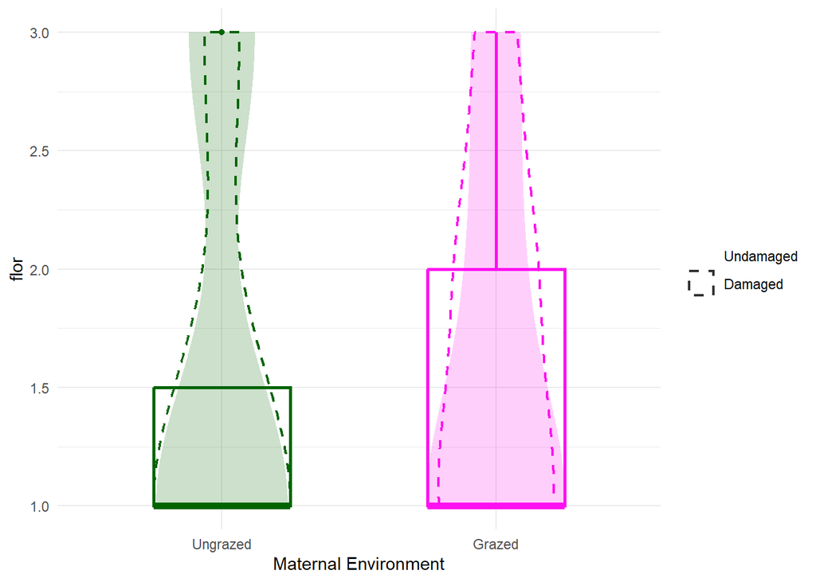

### H.murinum - PRODUCCIÓN DE FRUTOS

**sqrt(fruto) ~ trat + clip + trat:clip**  
n = **16** (43 0s removed)

[output not shown]

[output not shown]

[output not shown]

[output not shown]

[output not shown]

R² = **7.5801114^{-5}**

##### HOfruto Post-hoc Comparisons with Tukeys HSD

| contrast | trat | estimate | SE | df | t.ratio | p.value |
| --- | --- | --- | --- | --- | --- | --- |
| no - yes | ex | 0.2440169 | 0.1667072 | 12 | 1.4637460 | 0.1689613 |
| no - yes | gra | -0.0690356 | 0.1317936 | 12 | -0.5238161 | 0.6099448 |

| contrast | clip | estimate | SE | df | t.ratio | p.value |
| --- | --- | --- | --- | --- | --- | --- |
| ex - gra | no | 0.2440169 | 0.1559403 | 12 | 1.5648103 | 0.1436039 |
| ex - gra | yes | -0.0690356 | 0.1443726 | 12 | -0.4781764 | 0.6411179 |

ANOVA Results for HOfruto Model

| Response | Predictor | Sum Sq | Df | F value | Pr(>F) |
| --- | --- | --- | --- | --- | --- |
| HO fruto | trat | 0.021 | 1 | 0.507 | 0.490 |
| HO fruto | clip | 0.010 | 1 | 0.247 | 0.628 |
| HO fruto | trat:clip | 0.090 | 1 | 2.170 | 0.166 |
| HO fruto | Residuals | 0.500 | 12 | NA | NA |

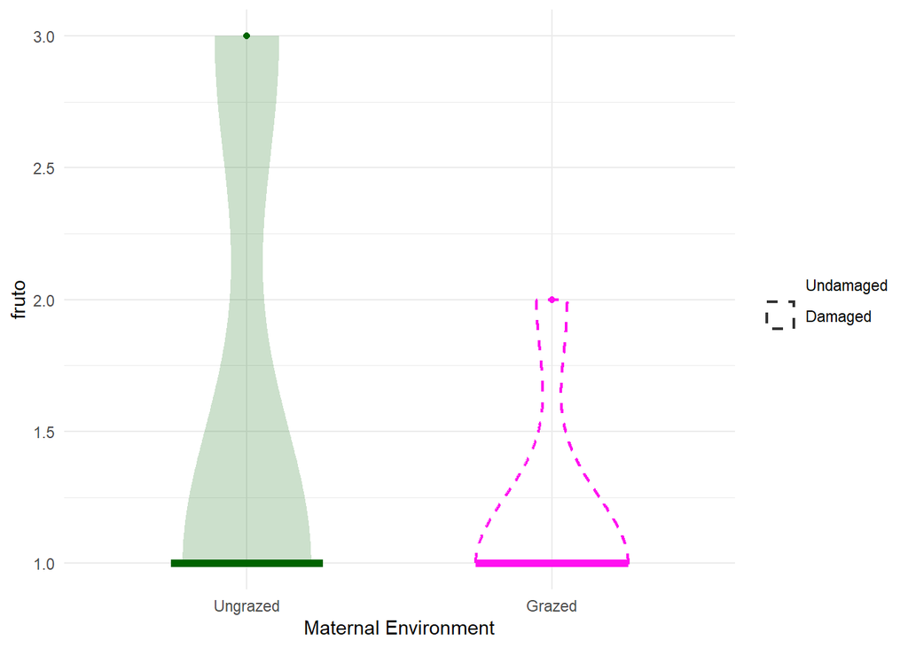

### H.murinum - PRODUCCIÓN DE HOJAS

**sqrt(hojas) ~ trat + clip + trat:clip**  
n = **57**

R² = **0.0195923**

##### HOhojas Post-hoc Comparisons with Tukeys HSD

| contrast | trat | estimate | SE | df | t.ratio | p.value |
| --- | --- | --- | --- | --- | --- | --- |
| no - yes | ex | -0.3973997 | 0.6595918 | 53 | -0.6024934 | 0.5494150 |
| no - yes | gra | 1.0276109 | 0.6996028 | 53 | 1.4688490 | 0.1477845 |

| contrast | clip | estimate | SE | df | t.ratio | p.value |
| --- | --- | --- | --- | --- | --- | --- |
| ex - gra | no | -1.3754485 | 0.6996028 | 53 | -1.9660421 | 0.0545415 |
| ex - gra | yes | 0.0495621 | 0.6595918 | 53 | 0.0751405 | 0.9403858 |

ANOVA Results for HOhojas Model

| Response | Predictor | Sum Sq | Df | F value | Pr(>F) |
| --- | --- | --- | --- | --- | --- |
| HO hojas | trat | 5.464 | 1 | 1.674 | 0.201 |
| HO hojas | clip | 1.057 | 1 | 0.324 | 0.572 |
| HO hojas | trat:clip | 7.167 | 1 | 2.196 | 0.144 |
| HO hojas | Residuals | 172.937 | 53 | NA | NA |

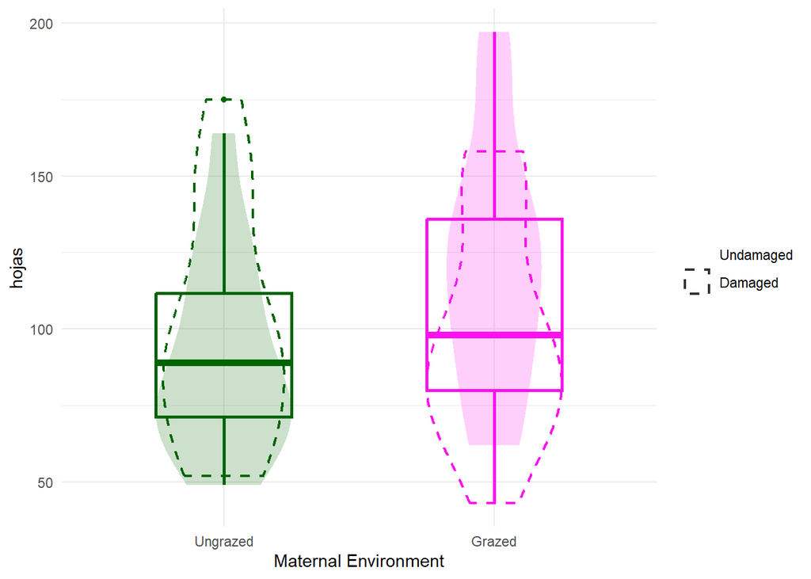

### H.murinum - ALTURA MÁXIMA

**sqrt(altura) ~ trat + clip + trat:clip**  
n = **27**

R² = **0.0473596**

##### HOaltura Post-hoc Comparisons with Tukeys HSD

| contrast | trat | estimate | SE | df | t.ratio | p.value |
| --- | --- | --- | --- | --- | --- | --- |
| no - yes | ex | 0.7388782 | 0.5055627 | 23 | 1.461497 | 0.1574081 |
| no - yes | gra | -0.7823731 | 0.5336706 | 23 | -1.466023 | 0.1561814 |

| contrast | clip | estimate | SE | df | t.ratio | p.value |
| --- | --- | --- | --- | --- | --- | --- |
| ex - gra | no | 0.9346288 | 0.5668489 | 23 | 1.648815 | 0.1127794 |
| ex - gra | yes | -0.5866225 | 0.4680601 | 23 | -1.253306 | 0.2226859 |

ANOVA Results for HOaltura Model

| Response | Predictor | Sum Sq | Df | F value | Pr(>F) |
| --- | --- | --- | --- | --- | --- |
| HO altura | trat | 0.006 | 1 | 0.007 | 0.934 |
| HO altura | clip | 0.002 | 1 | 0.003 | 0.958 |
| HO altura | trat:clip * | 3.753 | 1 | 4.282 | 0.050 |
| HO altura | Residuals | 20.155 | 23 | NA | NA |

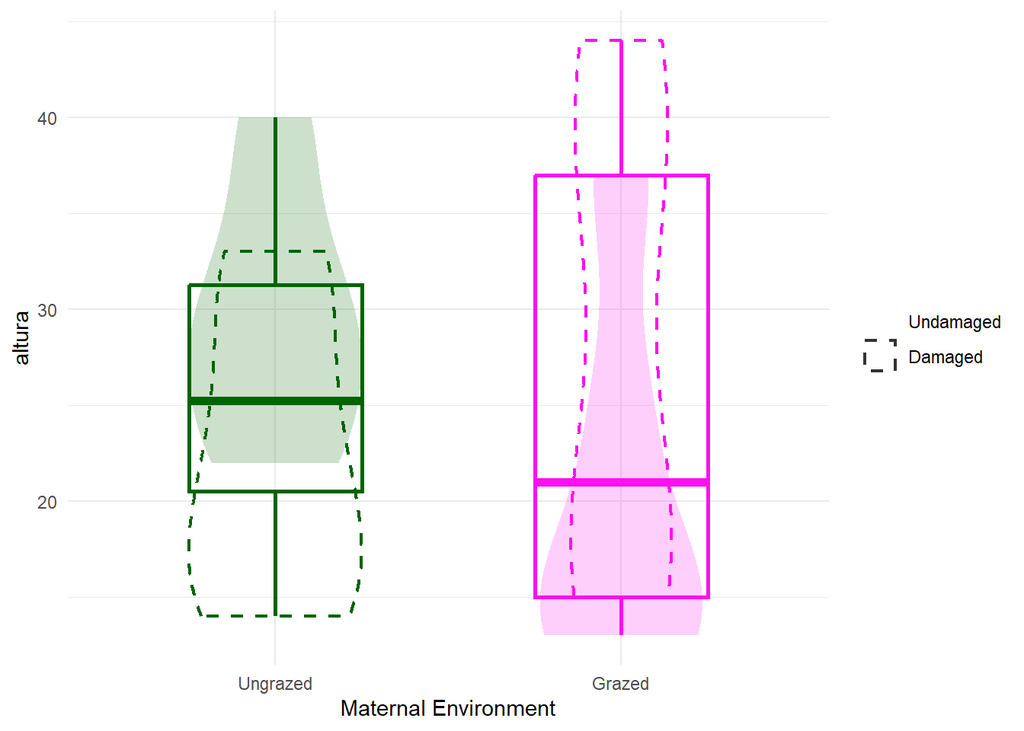

### H.murinum - SEMILLAS/FRUTO

**sqrt(seedfruto) ~ trat + clip + trat:clip**  
n = **9** (los resultados del ANOVA no tienen sentido porque algunos tratamientos solo tienen 1 o 2 réplicas)

R² = **0.5266359**

##### HOseedfruto Post-hoc Comparisons with Tukeys HSD

| contrast | trat | estimate | SE | df | t.ratio | p.value |
| --- | --- | --- | --- | --- | --- | --- |
| no - yes | ex | 0.5103899 | 0.5621155 | 5 | 0.9079804 | 0.4055239 |
| no - yes | gra | -1.5339403 | 0.5027714 | 5 | -3.0509697 | 0.0283929 |

| contrast | clip | estimate | SE | df | t.ratio | p.value |
| --- | --- | --- | --- | --- | --- | --- |
| ex - gra | no | 1.879873 | 0.5621155 | 5 | 3.3442828 | 0.0204564 |
| ex - gra | yes | -0.164457 | 0.5027714 | 5 | -0.3271009 | 0.7568418 |

ANOVA Results for HOseedfruto Model

| Response | Predictor | Sum Sq | Df | F value | Pr(>F) |
| --- | --- | --- | --- | --- | --- |
| HO seedfruto | trat | 0.831 | 1 | 3.943 | 0.104 |
| HO seedfruto | clip | 0.587 | 1 | 2.785 | 0.156 |
| HO seedfruto | trat:clip * | 1.548 | 1 | 7.348 | 0.042 |
| HO seedfruto | Residuals | 1.053 | 5 | NA | NA |

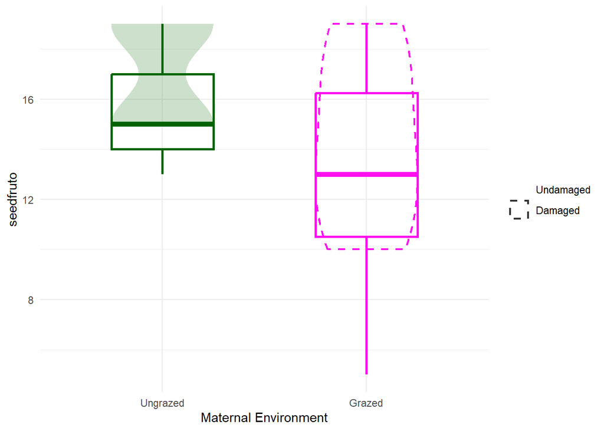

### H.murinum - PRODUCCIÓN DE SEMILLAS

R² = **0.6727296**

##### HOseedtotal Post-hoc Comparisons with Tukeys HSD

| contrast | trat | estimate | SE | df | t.ratio | p.value |
| --- | --- | --- | --- | --- | --- | --- |
| no - yes | ex | 0.5103899 | 0.3727705 | 6 | 1.369180 | 0.2199812 |
| no - yes | gra | -1.7959119 | 0.4083497 | 6 | -4.397976 | 0.0045784 |

| contrast | clip | estimate | SE | df | t.ratio | p.value |
| --- | --- | --- | --- | --- | --- | --- |
| ex - gra | no | 1.8798732 | 0.4565488 | 6 | 4.117573 | 0.0062332 |
| ex - gra | yes | -0.4264286 | 0.3118822 | 6 | -1.367275 | 0.2205450 |

ANOVA Results for HOseedtotal Model

| Response | Predictor | Sum Sq | Df | F value | Pr(>F) |
| --- | --- | --- | --- | --- | --- |
| HO seedtotal | trat | 0.198 | 1 | 1.425 | 0.278 |
| HO seedtotal | clip · | 0.531 | 1 | 3.818 | 0.099 |
| HO seedtotal | trat:clip ** | 2.418 | 1 | 17.399 | 0.006 |
| HO seedtotal | Residuals | 0.834 | 6 | NA | NA |

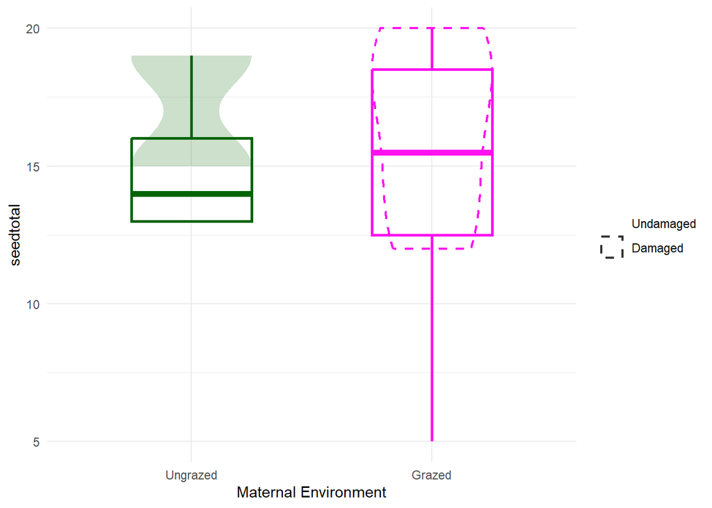

### H.murinum - PESO MEDIO DE LAS SEMILLAS

**sqrt(massseed) ~ trat + clip + trat:clip**  
n = **8**

[output not shown]

[output not shown]

[output not shown]

[output not shown]

[output not shown]

[output not shown]

[output not shown]

[output not shown]

[output not shown]

[output not shown]

[output not shown]

[output not shown]

[output not shown]

[output not shown]

[output not shown]

[output not shown]

[output not shown]

[output not shown]

[output not shown]

[output not shown]

[output not shown]

R² = **-0.1074254**

##### HOmassseed Post-hoc Comparisons with Tukeys HSD

| contrast | trat | estimate | SE | df | t.ratio | p.value |
| --- | --- | --- | --- | --- | --- | --- |
| no - yes | ex | -0.0007311 | 0.0128287 | 4 | -0.0569932 | 0.9572840 |
| no - yes | gra | 0.0018609 | 0.0117110 | 4 | 0.1589028 | 0.8814457 |

| contrast | clip | estimate | SE | df | t.ratio | p.value |
| --- | --- | --- | --- | --- | --- | --- |
| ex - gra | no | -0.0133146 | 0.0128287 | 4 | -1.0378729 | 0.3579475 |
| ex - gra | yes | -0.0107225 | 0.0117110 | 4 | -0.9155971 | 0.4116821 |

ANOVA Results for HOmassseed Model

| Response | Predictor | Sum Sq | Df | F value | Pr(>F) |
| --- | --- | --- | --- | --- | --- |
| HO massseed | trat | 0 | 1 | 1.893 | 0.241 |
| HO massseed | clip | 0 | 1 | 0.006 | 0.941 |
| HO massseed | trat:clip | 0 | 1 | 0.022 | 0.889 |
| HO massseed | Residuals | 0 | 4 | NA | NA |

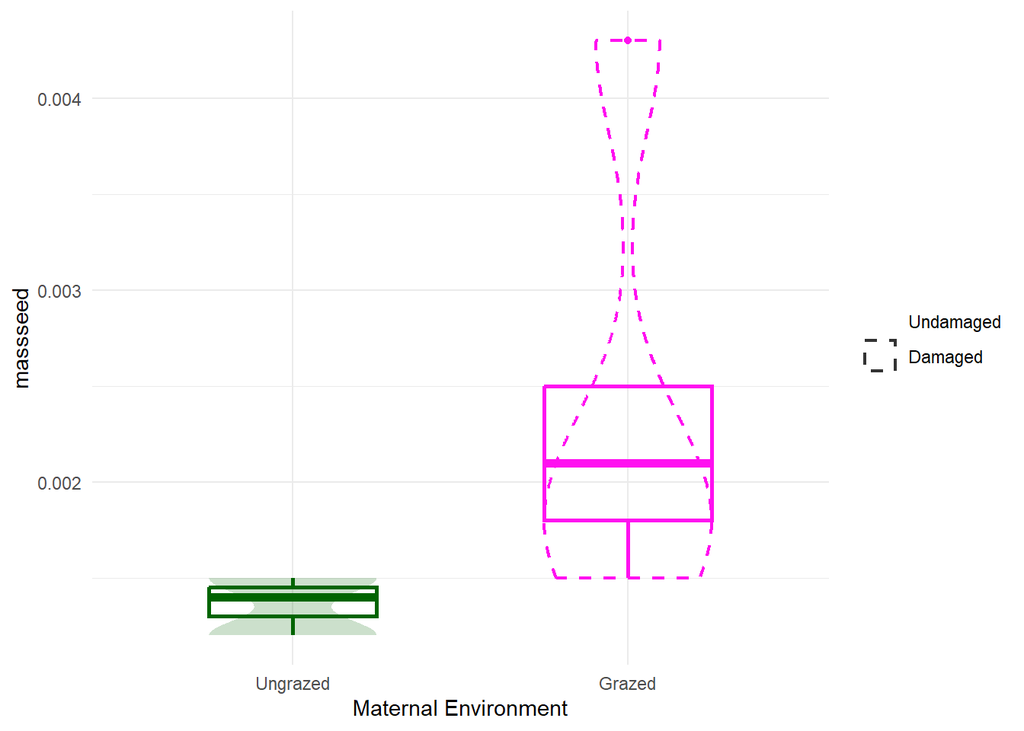

### H.murinum - SLA

**sqrt(SLA) ~ trat + clip + trat:clip**  
n = **50**

R² = **-0.0225313**

##### HOSLA Post-hoc Comparisons with Tukeys HSD

| contrast | trat | estimate | SE | df | t.ratio | p.value |
| --- | --- | --- | --- | --- | --- | --- |
| no - yes | ex | 0.2906665 | 0.9188578 | 46 | 0.3163345 | 0.7531796 |
| no - yes | gra | -0.9708964 | 0.8478471 | 46 | -1.1451314 | 0.2580778 |

| contrast | clip | estimate | SE | df | t.ratio | p.value |
| --- | --- | --- | --- | --- | --- | --- |
| ex - gra | no | 1.0880228 | 0.8812093 | 46 | 1.2346928 | 0.2232149 |
| ex - gra | yes | -0.1735401 | 0.8869130 | 46 | -0.1956676 | 0.8457322 |

ANOVA Results for HOSLA Model

| Response | Predictor | Sum Sq | Df | F value | Pr(>F) |
| --- | --- | --- | --- | --- | --- |
| HO SLA | trat | 2.639 | 1 | 0.545 | 0.464 |
| HO SLA | clip | 1.905 | 1 | 0.393 | 0.534 |
| HO SLA | trat:clip | 4.934 | 1 | 1.018 | 0.318 |
| HO SLA | Residuals | 222.895 | 46 | NA | NA |

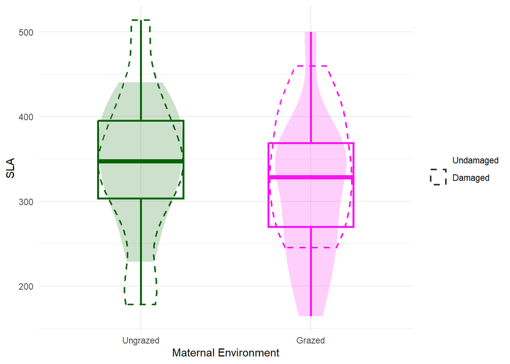

### H.murinum - LDMC

**sqrt(LDMC) ~ trat + clip + trat:clip**  
n = **48**

R² = **0.1414676**

##### HOLDMC Post-hoc Comparisons with Tukeys HSD

| contrast | trat | estimate | SE | df | t.ratio | p.value |
| --- | --- | --- | --- | --- | --- | --- |
| no - yes | ex | 0.0214318 | 0.0210768 | 44 | 1.016839 | 0.3147889 |
| no - yes | gra | 0.0254978 | 0.0185797 | 44 | 1.372346 | 0.1769114 |

| contrast | clip | estimate | SE | df | t.ratio | p.value |
| --- | --- | --- | --- | --- | --- | --- |
| ex - gra | no | -0.0422824 | 0.0197620 | 44 | -2.139587 | 0.0379733 |
| ex - gra | yes | -0.0382164 | 0.0199726 | 44 | -1.913444 | 0.0622114 |

ANOVA Results for HOLDMC Model

| Response | Predictor | Sum Sq | Df | F value | Pr(>F) |
| --- | --- | --- | --- | --- | --- |
| HO LDMC | trat ** | 0.019 | 1 | 8.218 | 0.006 |
| HO LDMC | clip · | 0.007 | 1 | 2.896 | 0.096 |
| HO LDMC | trat:clip | 0.000 | 1 | 0.021 | 0.886 |
| HO LDMC | Residuals | 0.102 | 44 | NA | NA |

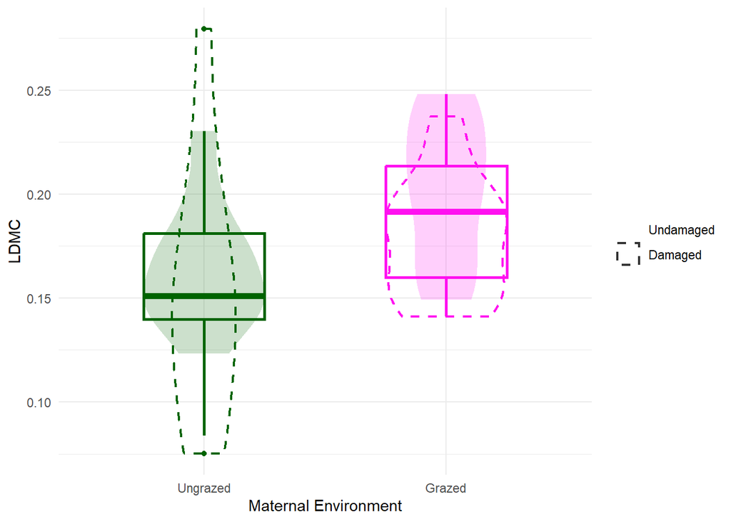

### H.murinum - ÁREA FOLIAR

**sqrt(area.m) ~ trat + clip + trat:clip**  
n = **51**

R² = **0.0235085**

##### HOarea.m Post-hoc Comparisons with Tukeys HSD

| contrast | trat | estimate | SE | df | t.ratio | p.value |
| --- | --- | --- | --- | --- | --- | --- |
| no - yes | ex | 0.2201190 | 0.2025968 | 47 | 1.0864879 | 0.2828042 |
| no - yes | gra | -0.0309609 | 0.1911413 | 47 | -0.1619793 | 0.8720165 |

| contrast | clip | estimate | SE | df | t.ratio | p.value |
| --- | --- | --- | --- | --- | --- | --- |
| ex - gra | no | 0.3671323 | 0.1986625 | 47 | 1.8480199 | 0.0708974 |
| ex - gra | yes | 0.1160524 | 0.1952272 | 47 | 0.5944479 | 0.5550635 |

ANOVA Results for HOarea.m Model

| Response | Predictor | Sum Sq | Df | F value | Pr(>F) |
| --- | --- | --- | --- | --- | --- |
| HO area.m | trat · | 0.728 | 1 | 2.956 | 0.092 |
| HO area.m | clip | 0.097 | 1 | 0.394 | 0.533 |
| HO area.m | trat:clip | 0.200 | 1 | 0.813 | 0.372 |
| HO area.m | Residuals | 11.575 | 47 | NA | NA |

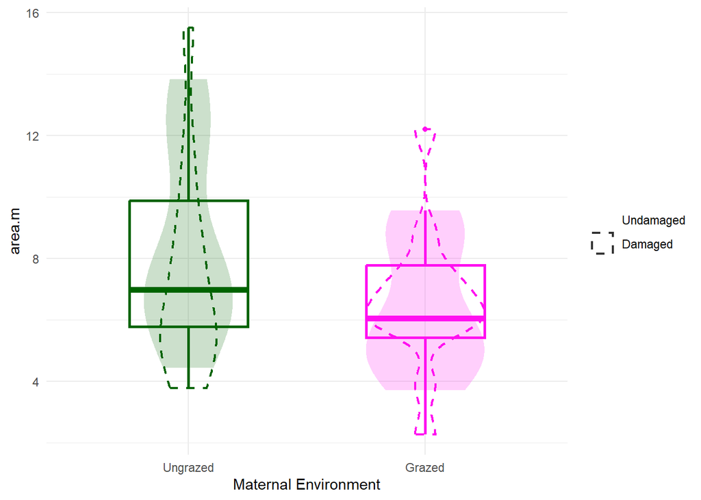

### H.murinum - TASA FOTOSINTÉTICA

**sqrt(Photosyn) ~ trat + clip + trat:clip**  
n = **29**

R² = **-0.0179436**

##### HOPhotosyn Post-hoc Comparisons with Tukeys HSD

| contrast | trat | estimate | SE | df | t.ratio | p.value |
| --- | --- | --- | --- | --- | --- | --- |
| no - yes | ex | -0.1524151 | 0.4482184 | 25 | -0.3400465 | 0.7366621 |
| no - yes | gra | -0.6896924 | 0.5110476 | 25 | -1.3495660 | 0.1892504 |

| contrast | clip | estimate | SE | df | t.ratio | p.value |
| --- | --- | --- | --- | --- | --- | --- |
| ex - gra | no | 0.4416535 | 0.4482184 | 25 | 0.9853534 | 0.3338915 |
| ex - gra | yes | -0.0956239 | 0.5110476 | 25 | -0.1871134 | 0.8530820 |

ANOVA Results for HOPhotosyn Model

| Response | Predictor | Sum Sq | Df | F value | Pr(>F) |
| --- | --- | --- | --- | --- | --- |
| HO Photosyn | trat | 0.306 | 1 | 0.381 | 0.543 |
| HO Photosyn | clip | 1.055 | 1 | 1.312 | 0.263 |
| HO Photosyn | trat:clip | 0.502 | 1 | 0.625 | 0.437 |
| HO Photosyn | Residuals | 20.090 | 25 | NA | NA |

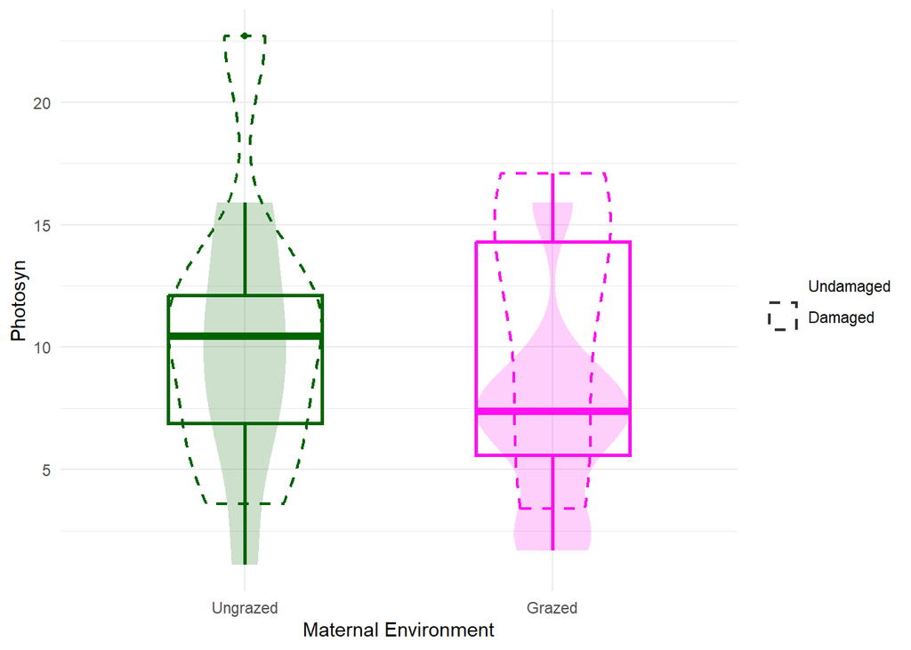

### H.murinum - CONDUCTANCIA ESTOMÁTICA

**sqrt(Conductance) ~ trat + clip + trat:clip**  
n = **29**

R² = **-0.0044172**

##### HOConductance Post-hoc Comparisons with Tukeys HSD

| contrast | trat | estimate | SE | df | t.ratio | p.value |
| --- | --- | --- | --- | --- | --- | --- |
| no - yes | ex | -0.0014907 | 0.0415074 | 25 | -0.0359149 | 0.9716355 |
| no - yes | gra | -0.0637175 | 0.0473258 | 25 | -1.3463605 | 0.1902676 |

| contrast | clip | estimate | SE | df | t.ratio | p.value |
| --- | --- | --- | --- | --- | --- | --- |
| ex - gra | no | -0.0081957 | 0.0415074 | 25 | -0.1974505 | 0.8450716 |
| ex - gra | yes | -0.0704225 | 0.0473258 | 25 | -1.4880366 | 0.1492475 |

ANOVA Results for HOConductance Model

| Response | Predictor | Sum Sq | Df | F value | Pr(>F) |
| --- | --- | --- | --- | --- | --- |
| HO Conductance | trat | 0.009 | 1 | 1.276 | 0.269 |
| HO Conductance | clip | 0.006 | 1 | 0.837 | 0.369 |
| HO Conductance | trat:clip | 0.007 | 1 | 0.977 | 0.332 |
| HO Conductance | Residuals | 0.172 | 25 | NA | NA |

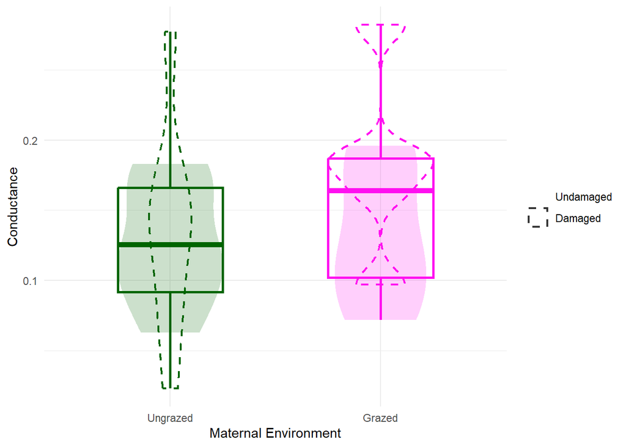

### H.murinum - EFICIENCIA DEL FOTOSISTEMA II

**sqrt(PhiPS2) ~ trat + clip + trat:clip**  
n = **29**

R² = **0.1440176**

##### HOPhiPS2 Post-hoc Comparisons with Tukeys HSD

| contrast | trat | estimate | SE | df | t.ratio | p.value |
| --- | --- | --- | --- | --- | --- | --- |
| no - yes | ex | 0.0261526 | 0.0315912 | 25 | 0.8278432 | 0.4155923 |
| no - yes | gra | -0.0688384 | 0.0360195 | 25 | -1.9111421 | 0.0675170 |

| contrast | clip | estimate | SE | df | t.ratio | p.value |
| --- | --- | --- | --- | --- | --- | --- |
| ex - gra | no | -0.0037768 | 0.0315912 | 25 | -0.119551 | 0.9057944 |
| ex - gra | yes | -0.0987678 | 0.0360195 | 25 | -2.742062 | 0.0111178 |

ANOVA Results for HOPhiPS2 Model

| Response | Predictor | Sum Sq | Df | F value | Pr(>F) |
| --- | --- | --- | --- | --- | --- |
| HO PhiPS2 | trat · | 0.014 | 1 | 3.602 | 0.069 |
| HO PhiPS2 | clip | 0.002 | 1 | 0.407 | 0.529 |
| HO PhiPS2 | trat:clip · | 0.016 | 1 | 3.931 | 0.058 |
| HO PhiPS2 | Residuals | 0.100 | 25 | NA | NA |

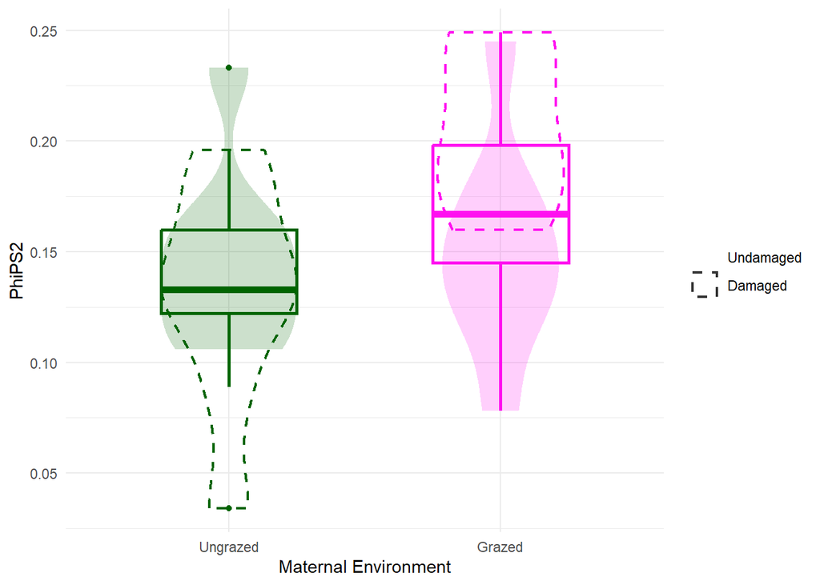

### H.murinum - FENOLOGÍA DE FLORACIÓN

**sqrt(dias_flor) ~ trat + clip + trat:clip**  
n = **24**

[output not shown]

[output not shown]

[output not shown]

R² = **0.1271542**

##### HOdias_flor Post-hoc Comparisons with Tukeys HSD

| contrast | trat | estimate | SE | df | t.ratio | p.value |
| --- | --- | --- | --- | --- | --- | --- |
| no - yes | ex | 0.2311643 | 0.5361314 | 20 | 0.4311711 | 0.6709557 |
| no - yes | gra | 1.1156516 | 0.4531137 | 20 | 2.4621891 | 0.0230142 |

| contrast | clip | estimate | SE | df | t.ratio | p.value |
| --- | --- | --- | --- | --- | --- | --- |
| ex - gra | no | -0.3299821 | 0.4963612 | 20 | -0.6648023 | 0.5137703 |
| ex - gra | yes | 0.5545052 | 0.4963612 | 20 | 1.1171405 | 0.2771754 |

ANOVA Results for HOdias_flor Model

| Response | Predictor | Sum Sq | Df | F value | Pr(>F) |
| --- | --- | --- | --- | --- | --- |
| HO dias_flor | trat | 0.074 | 1 | 0.102 | 0.752 |
| HO dias_flor | clip * | 3.349 | 1 | 4.661 | 0.043 |
| HO dias_flor | trat:clip | 1.141 | 1 | 1.588 | 0.222 |
| HO dias_flor | Residuals | 14.372 | 20 | NA | NA |

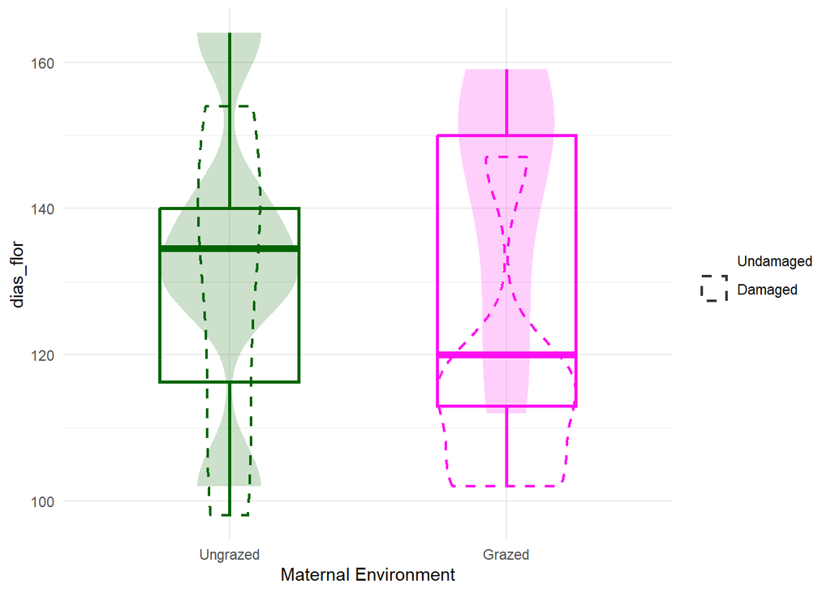

### H.murinum - FENOLOGÍA DE FRUCTIFICACÓN

**sqrt(dias_fruto) ~ trat + clip + trat:clip**  
n = **15**

R² = **0.0296056**

##### HOdias_fruto Post-hoc Comparisons with Tukeys HSD

| contrast | trat | estimate | SE | df | t.ratio | p.value |
| --- | --- | --- | --- | --- | --- | --- |
| no - yes | ex | 0.3215534 | 0.7692118 | 11 | 0.4180297 | 0.6839695 |
| no - yes | gra | 0.9295372 | 0.5439149 | 11 | 1.7089754 | 0.1154808 |

| contrast | clip | estimate | SE | df | t.ratio | p.value |
| --- | --- | --- | --- | --- | --- | --- |
| ex - gra | no | -0.6306305 | 0.7297384 | 11 | -0.8641870 | 0.4059356 |
| ex - gra | yes | -0.0226467 | 0.5958289 | 11 | -0.0380087 | 0.9703618 |

ANOVA Results for HOdias_fruto Model

| Response | Predictor | Sum Sq | Df | F value | Pr(>F) |
| --- | --- | --- | --- | --- | --- |
| HO dias_fruto | trat | 0.236 | 1 | 0.332 | 0.576 |
| HO dias_fruto | clip | 1.902 | 1 | 2.679 | 0.130 |
| HO dias_fruto | trat:clip | 0.296 | 1 | 0.416 | 0.532 |
| HO dias_fruto | Residuals | 7.810 | 11 | NA | NA |

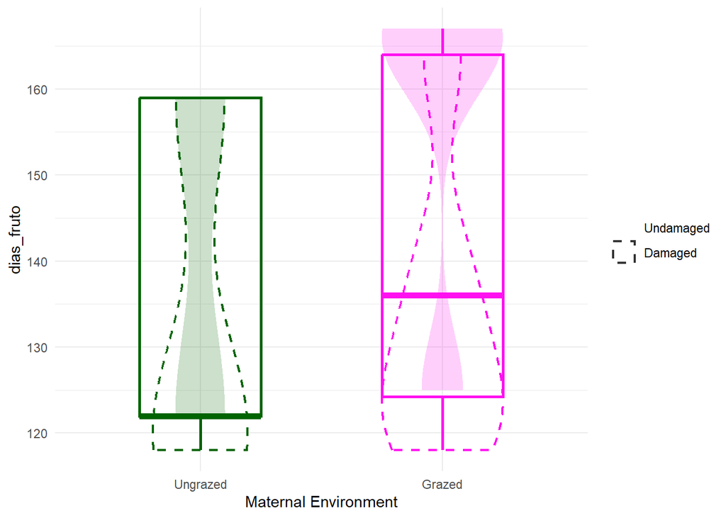

### H.murinum - PERIODO DE FLORACIÓN

**sqrt(periodo_flor) ~ trat + clip + trat:clip**  
n = **7**

R² = **0.046091**

##### HOperiodo_flor Post-hoc Comparisons with Tukeys HSD

| contrast | trat | estimate | SE | df | t.ratio | p.value |
| --- | --- | --- | --- | --- | --- | --- |
| no - yes | ex | NA | NA | NA | NA | NA |
| no - yes | gra | -0.3656408 | 0.5520123 | 4 | -0.662378 | 0.5439454 |

| contrast | clip | estimate | SE | df | t.ratio | p.value |
| --- | --- | --- | --- | --- | --- | --- |
| ex - gra | no | NA | NA | NA | NA | NA |
| ex - gra | yes | 0.8107305 | 0.7806633 | 4 | 1.038515 | 0.3576822 |

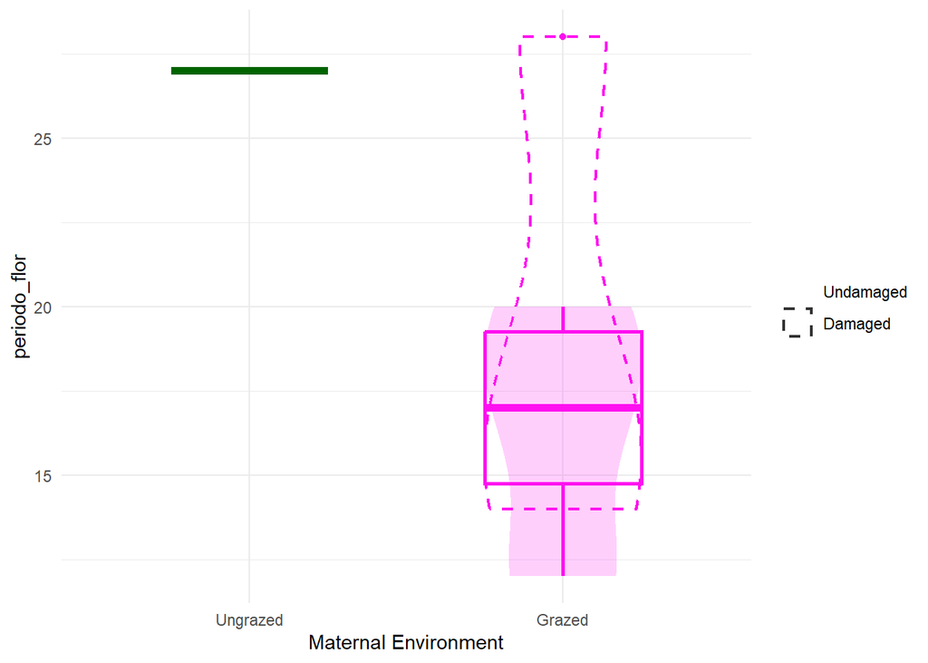

### H.murinum - PERIODO DE FRUCTIFICACIÓN

**sqrt(periodo_fruto) ~ trat + clip + trat:clip**

n = **8**

R² = **-0.4212377**

##### HOperiodo_fruto Post-hoc Comparisons with Tukeys HSD

| contrast | trat | estimate | SE | df | t.ratio | p.value |
| --- | --- | --- | --- | --- | --- | --- |
| no - yes | ex | 1.980346 | 3.627305 | 4 | 0.5459551 | 0.6141181 |
| no - yes | gra | 1.055220 | 2.703634 | 4 | 0.3902969 | 0.7162102 |

| contrast | clip | estimate | SE | df | t.ratio | p.value |
| --- | --- | --- | --- | --- | --- | --- |
| ex - gra | no | 1.5174851 | 2.961683 | 4 | 0.5123727 | 0.6353846 |
| ex - gra | yes | 0.5923591 | 3.419856 | 4 | 0.1732117 | 0.8708969 |

ANOVA Results for HOperiodo_fruto Model

| Response | Predictor | Sum Sq | Df | F value | Pr(>F) |
| --- | --- | --- | --- | --- | --- |
| HO periodo_fruto | trat | 2.199 | 1 | 0.251 | 0.643 |
| HO periodo_fruto | clip | 3.584 | 1 | 0.409 | 0.557 |
| HO periodo_fruto | trat:clip | 0.367 | 1 | 0.042 | 0.848 |
| HO periodo_fruto | Residuals | 35.086 | 4 | NA | NA |

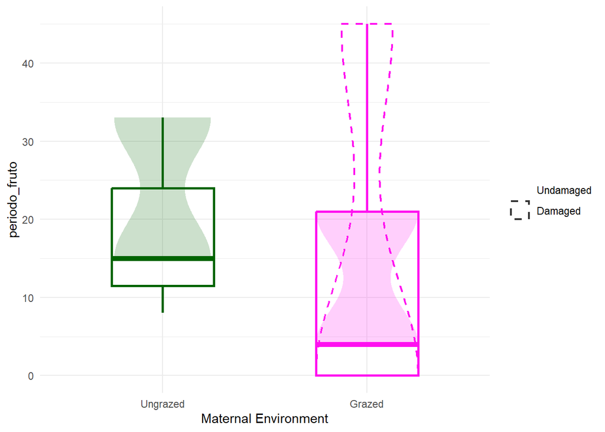

### H.murinum - ESPERANZA DE VIDA

**sqrt(dias_muerte) ~ trat + clip + trat:clip**  
n = **21**

R² = **-0.0675681**

##### HOdias_muerte Post-hoc Comparisons with Tukeys HSD

| contrast | trat | estimate | SE | df | t.ratio | p.value |
| --- | --- | --- | --- | --- | --- | --- |
| no - yes | ex | -0.3435818 | 0.5789439 | 17 | -0.5934630 | 0.5606852 |
| no - yes | gra | 0.5951763 | 0.6046872 | 17 | 0.9842714 | 0.3387842 |

| contrast | clip | estimate | SE | df | t.ratio | p.value |
| --- | --- | --- | --- | --- | --- | --- |
| ex - gra | no | -0.7222859 | 0.5789439 | 17 | -1.2475922 | 0.2290934 |
| ex - gra | yes | 0.2164722 | 0.6046872 | 17 | 0.3579904 | 0.7247569 |

ANOVA Results for HOdias_muerte Model

| Response | Predictor | Sum Sq | Df | F value | Pr(>F) |
| --- | --- | --- | --- | --- | --- |
| HO dias_muerte | trat | 0.390 | 1 | 0.427 | 0.522 |
| HO dias_muerte | clip | 0.058 | 1 | 0.064 | 0.804 |
| HO dias_muerte | trat:clip | 1.149 | 1 | 1.257 | 0.278 |
| HO dias_muerte | Residuals | 15.540 | 17 | NA | NA |

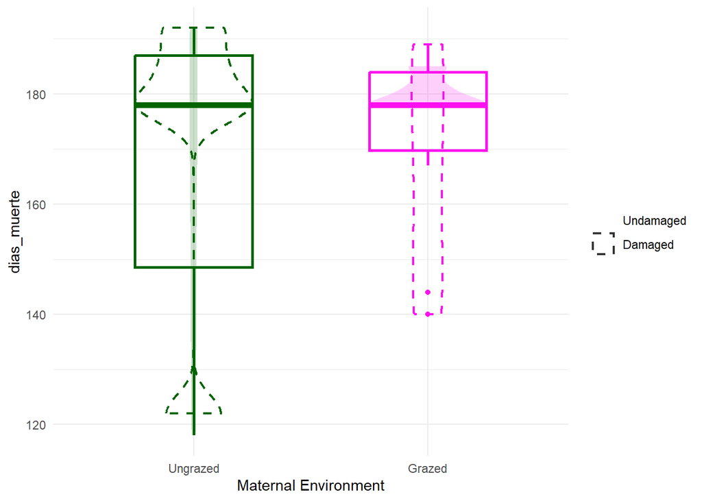

### H.murinum - FENOLES

**fenoles ~ trat + clip + trat:clip**  
n = **40** he quitado dos outliers que supongo se deben a algún error (¿3 y 170?)

[output not shown]

[output not shown]

[output not shown]

[output not shown]

[output not shown]

[output not shown]

[output not shown]

[output not shown]

[output not shown]

[output not shown]

[output not shown]

[output not shown]

[output not shown]

[output not shown]

[output not shown]

[output not shown]

[output not shown]

[output not shown]

[output not shown]

[output not shown]

[output not shown]

[output not shown]

[output not shown]

[output not shown]

[output not shown]

[output not shown]

[output not shown]

[output not shown]

[output not shown]

[output not shown]

[output not shown]

[output not shown]

[output not shown]

[output not shown]

[output not shown]

[output not shown]

[output not shown]

[output not shown]

[output not shown]

R² = **0.0819845**

##### HOfenoles Post-hoc Comparisons with Tukeys HSD

| contrast | trat | estimate | SE | df | t.ratio | p.value |
| --- | --- | --- | --- | --- | --- | --- |
| no - yes | ex | 2.9259 | 2.348641 | 36 | 1.245784 | 0.2208907 |
| no - yes | gra | 4.4731 | 2.348641 | 36 | 1.904548 | 0.0648535 |

| contrast | clip | estimate | SE | df | t.ratio | p.value |
| --- | --- | --- | --- | --- | --- | --- |
| ex - gra | no | 1.1226 | 2.348641 | 36 | 0.4779785 | 0.6355553 |
| ex - gra | yes | 2.6698 | 2.348641 | 36 | 1.1367423 | 0.2631563 |

ANOVA Results for HOfenoles Model

| Response | Predictor | Sum Sq | Df | F value | Pr(>F) |
| --- | --- | --- | --- | --- | --- |
| HO fenoles | trat | 35.956 | 1 | 1.304 | 0.261 |
| HO fenoles | clip * | 136.863 | 1 | 4.962 | 0.032 |
| HO fenoles | trat:clip | 5.985 | 1 | 0.217 | 0.644 |
| HO fenoles | Residuals | 992.901 | 36 | NA | NA |

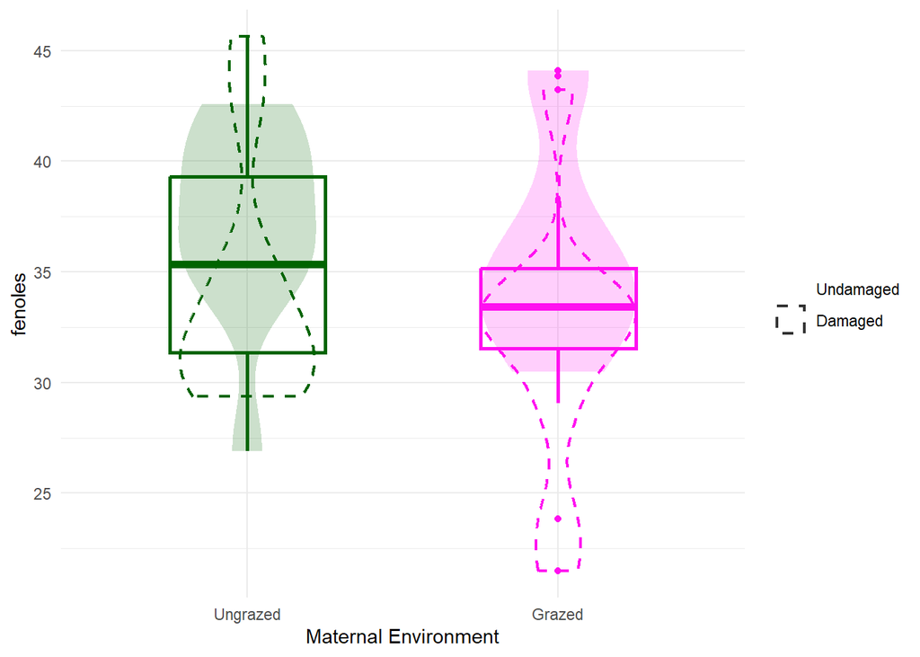